# 1 Instructions

Load Required Packages:

```r
library(tidyverse)
```

# 2 Basics

## 2.1 Exercise 1: Visualizing the `mtcars` dataset

**Objective:** Create a scatter plot of miles-per-gallon (`mpg`) against horsepower (`hp`), colored by the number of cylinders (`cyl`).

**Load Dataset:**

```r
data(mtcars)
```

**Solution Code:**

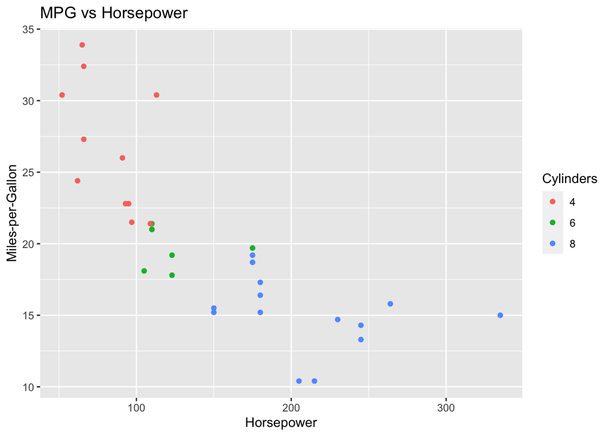

```r
library(ggplot2)

plot1 <- ggplot(mtcars, aes(x = hp, y = mpg, color = as.factor(cyl))) +
  geom_point() +
  labs(title = "MPG vs Horsepower", x = "Horsepower", y = "Miles-per-Gallon", color = "Cylinders")

print(plot1)
```

## 2.2 Exercise 2: Plotting the `iris` dataset

**Objective:** Create a boxplot showing the distribution of petal lengths (`Petal.Length`) for each species (`Species`).

**Load Dataset:**

```r
data(iris)
```

**Solution Code:**

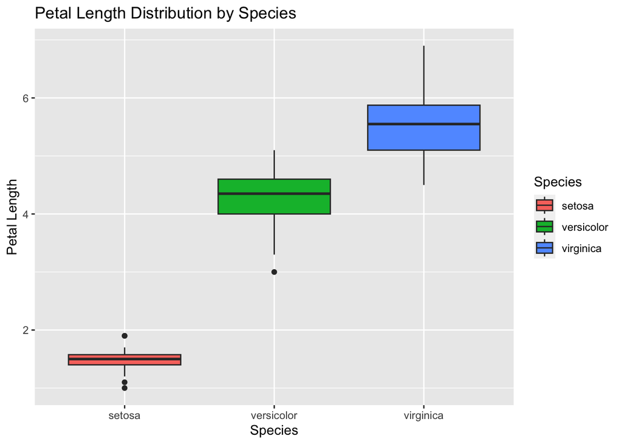

```r
plot2 <- ggplot(iris, aes(x = Species, y = Petal.Length, fill = Species)) +
  geom_boxplot() +
  labs(title = "Petal Length Distribution by Species", x = "Species", y = "Petal Length")

print(plot2)
```

## 2.3 Exercise 3: Diving into the `diamonds` dataset

**Objective:** Create a histogram of diamond prices (`price`), filled by diamond cut (`cut`).

**Load Dataset:**

```r
library(ggplot2)
data(diamonds)
```

**Solution Code:**

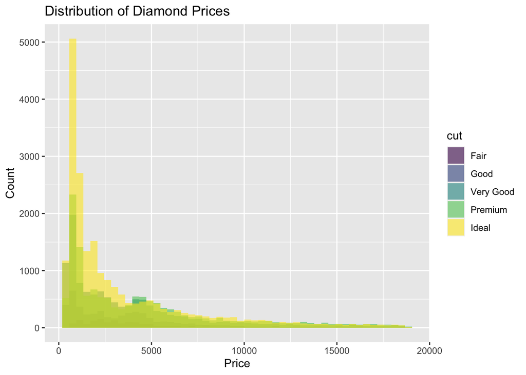

```r
plot3 <- ggplot(diamonds, aes(x = price, fill = cut)) +
  geom_histogram(position = "identity", alpha = 0.6, bins = 50) +
  labs(title = "Distribution of Diamond Prices", x = "Price", y = "Count")

print(plot3)
```

## 2.4 Exercise 4: Illustrating the `airquality` dataset

**Objective:** Plot the average ozone level (`Ozone`) for each month (`Month`), ignoring missing values. Use a bar chart.

**Load Dataset:**

```r
data(airquality)
```

**Solution Code:**

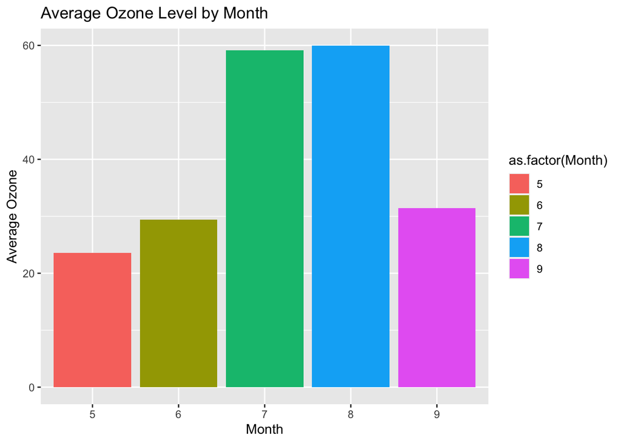

```r
library(dplyr)

aq_avg <- airquality %>%
  group_by(Month) %>%
  summarize(average_ozone = mean(Ozone, na.rm = TRUE))

plot4 <- ggplot(aq_avg, aes(x = as.factor(Month), y = average_ozone, fill = as.factor(Month))) +
  geom_bar(stat = "identity") +
  labs(title = "Average Ozone Level by Month", x = "Month", y = "Average Ozone")

print(plot4)
```

## 2.5 Exercise 5: Inspecting the `ChickWeight` dataset

**Objective:** Create a line plot that shows the progression of weight (`weight`) over time (`Time`) for chicks fed Diet 1.

**Load Dataset:**

```r
data(ChickWeight)
```

**Solution Code:**

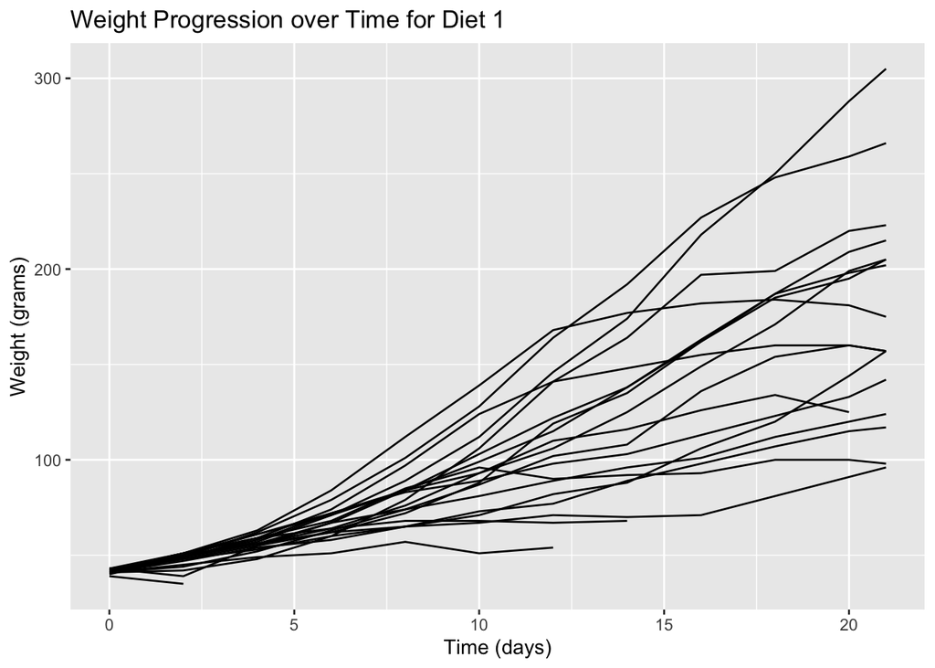

```r
plot5 <- ggplot(ChickWeight %>% filter(Diet == 1), aes(x = Time, y = weight, group = Chick)) +
  geom_line() +
  labs(title = "Weight Progression over Time for Diet 1", x = "Time (days)", y = "Weight (grams)")

print(plot5)
```

# 3 Faceted figures

Certainly! Here are some exercises involving the creation of faceted figures using the `ggplot2` package in R:

## 3.1 Exercise 1: Visualizing the `mtcars` dataset

**Objective:** Create a scatter plot of miles-per-gallon (`mpg`) against weight (`wt`), colored by the number of gears (`gear`). Facet the plot by the number of cylinders (`cyl`).

**Load Dataset:**

```r
data(mtcars)
```

**Solution Code:**

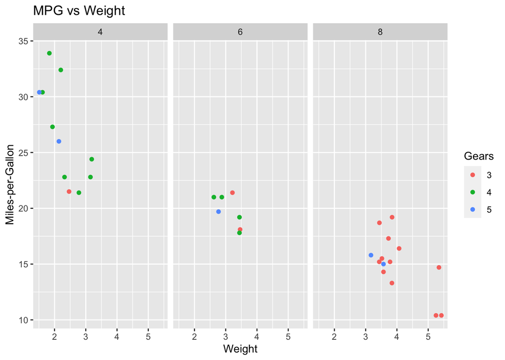

```r
library(ggplot2)

plot1 <- ggplot(mtcars, aes(x = wt, y = mpg, color = as.factor(gear))) +
  geom_point() +
  labs(title = "MPG vs Weight", x = "Weight", y = "Miles-per-Gallon", color = "Gears") +
  facet_wrap(~cyl)

print(plot1)
```

## 3.2 Exercise 2: Working with the `diamonds` dataset

**Objective:** Create a boxplot of diamond prices (`price`) for each diamond cut (`cut`). Facet the plot by diamond color (`color`).

**Load Dataset:**

```r
library(ggplot2)
data(diamonds)
```

**Solution Code:**

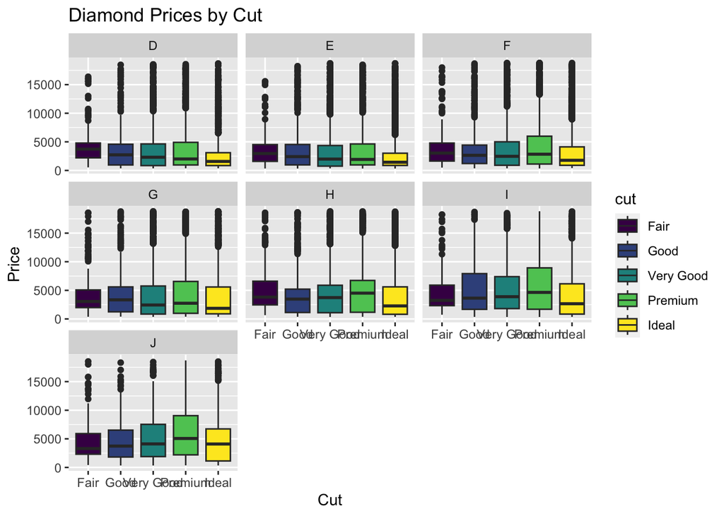

```r
plot2 <- ggplot(diamonds, aes(x = cut, y = price, fill = cut)) +
  geom_boxplot() +
  labs(title = "Diamond Prices by Cut", x = "Cut", y = "Price") +
  facet_wrap(~color)

print(plot2)
```

## 3.3 Exercise 3: Analyzing the `ChickWeight` dataset

**Objective:** Plot the progression of weight (`weight`) over time (`Time`) for each chick using a line plot. Facet the visualization by the diet type (`Diet`).

**Load Dataset:**

```r
data(ChickWeight)
```

**Solution Code:**

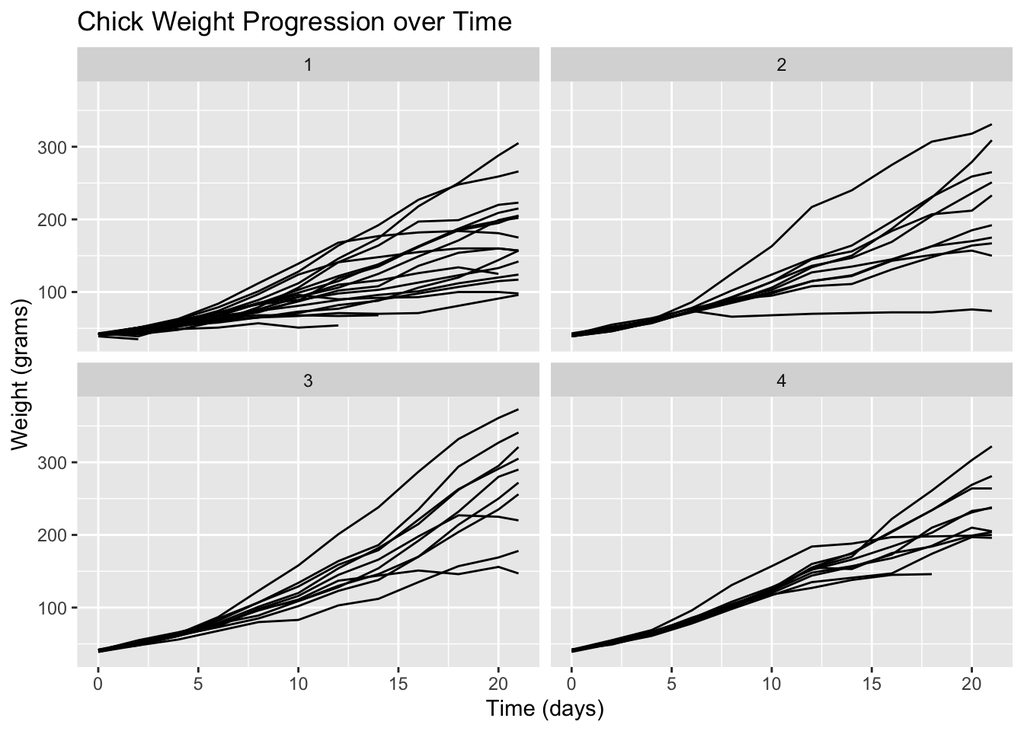

```r
plot3 <- ggplot(ChickWeight, aes(x = Time, y = weight, group = Chick)) +
  geom_line() +
  labs(title = "Chick Weight Progression over Time", x = "Time (days)", y = "Weight (grams)") +
  facet_wrap(~Diet)

print(plot3)
```

## 3.4 Exercise 4: Investigating the `mpg` dataset from the `ggplot2` package

**Objective:** Create a scatter plot of highway miles-per-gallon (`hwy`) against engine displacement (`displ`). Facet the plot by the drive type (`drv`), with different panels for each type of drive (front-wheel drive, rear-wheel drive, and four-wheel drive).

**Load Dataset:**

```r
library(ggplot2)
data(mpg)
```

**Solution Code:**

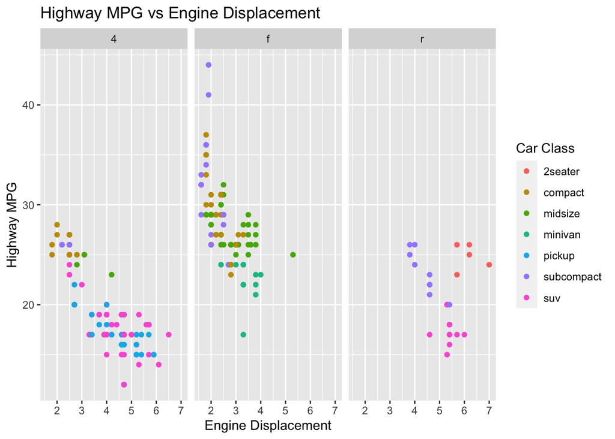

```r
plot4 <- ggplot(mpg, aes(x = displ, y = hwy)) +
  geom_point(aes(color = class)) +
  labs(title = "Highway MPG vs Engine Displacement", x = "Engine Displacement", y = "Highway MPG", color = "Car Class") +
  facet_wrap(~drv)

print(plot4)
```

## 3.5 Exercise 5: Exploring the `InsectSprays` dataset

**Objective:** Plot a boxplot showing the count of insects (`count`) for each spray type (`spray`). Facet the plot by spray type.

**Load Dataset:**

```r
data(InsectSprays)
```

**Solution Code:**

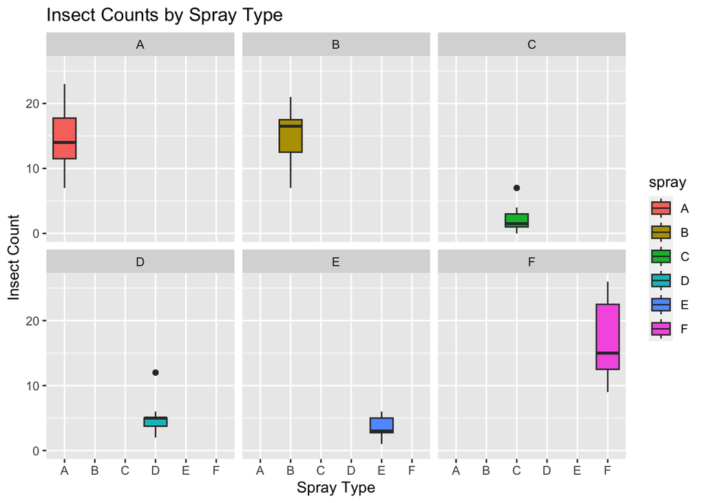

```r
plot5 <- ggplot(InsectSprays, aes(x = spray, y = count, fill = spray)) +
  geom_boxplot() +
  labs(title = "Insect Counts by Spray Type", x = "Spray Type", y = "Insect Count") +
  facet_wrap(~spray)

print(plot5)
```

# 4 More exercises with emphasis on adjusting figure appearence

## 4.1 Exercise 1: Colorful `mtcars` Scatter Plot

**Objective:** - Create a scatter plot of miles-per-gallon (`mpg`) against horsepower (`hp`). - Use a color scheme that displays a gradient based on `hp`. - Adjust the title text size and color.

**Required Functions:** - `ggplot`, `geom_point`, `scale_color_gradient`, `labs`, `theme`, `element_text`

**Load Dataset:**

```r
data(mtcars)
```

**Solution Code:**

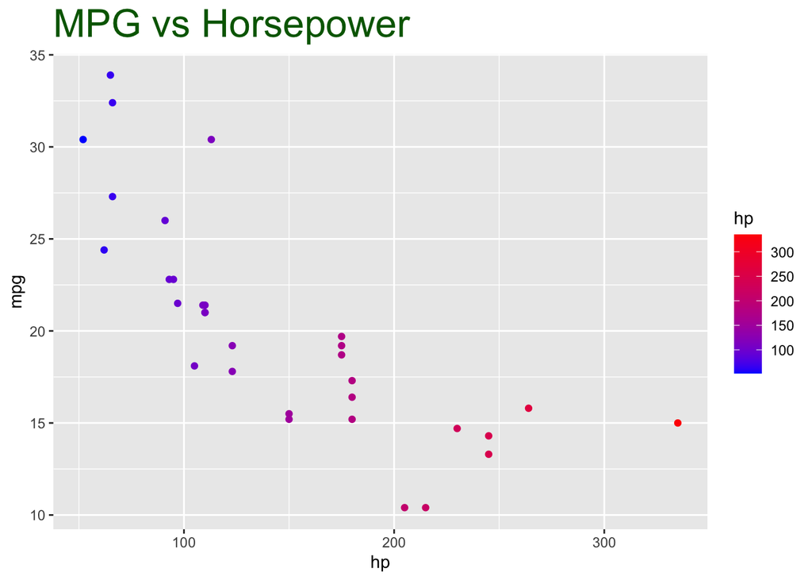

```r
library(ggplot2)

plot1 <- ggplot(mtcars, aes(x = hp, y = mpg, color = hp)) +
  geom_point() +
  scale_color_gradient(low = "blue", high = "red") +
  labs(title = "MPG vs Horsepower") +
  theme(plot.title = element_text(size = 24, color = "darkgreen"))

print(plot1)
```

## 4.2 Exercise 2: Stylish `iris` Boxplot

**Required Functions:** - `ggplot`, `geom_boxplot`, `scale_fill_manual`, `labs`, `theme`

**Load Dataset:**

```r
data(iris)
```

**Solution Code:**

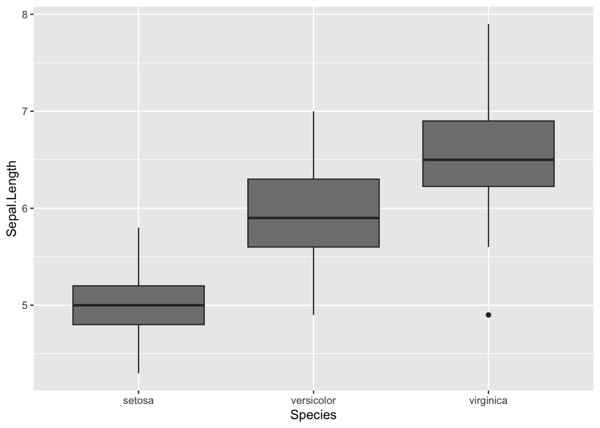

```r
plot2 <- ggplot(iris, aes(x = Species, y = Sepal.Length, fill = Species)) +
  geom_boxplot() +
  scale_fill_manual(values = c("Setosa" = "purple", "Versicolor" = "orange", "Virginica" = "green")) +
  theme(legend.position = "none")

print(plot2)
```

## 4.3 Exercise 3: Aesthetic `diamonds` Histogram

**Objective:** - Design a histogram for diamond prices (`price`). - Set bin colors to a specified hue, and the fill to another. - Increase the x-axis and y-axis label text size.

**Required Functions:** - `ggplot`, `geom_histogram`, `labs`, `theme`, `element_text`

**Load Dataset:**

```r
library(ggplot2)
data(diamonds)
```

**Solution Code:**

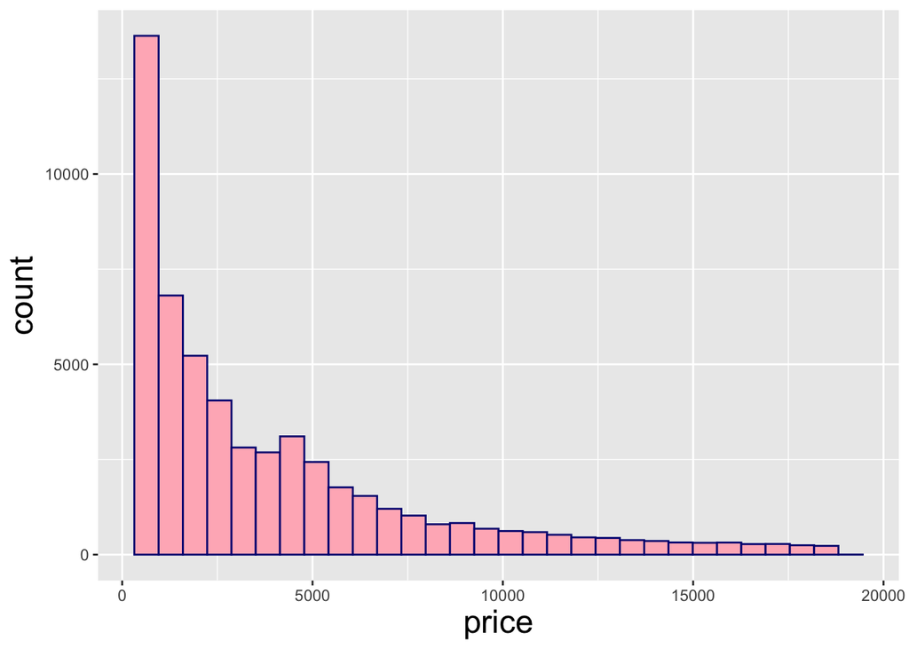

```r
plot3 <- ggplot(diamonds, aes(x = price)) +
  geom_histogram(color = "navy", fill = "lightpink", bins = 30) +
  theme(
    axis.title.x = element_text(size = 18),
    axis.title.y = element_text(size = 18)
  )

print(plot3)
```

## 4.4 Exercise 4: Shaped `mpg` Scatter Plot

**Objective:** - Produce a scatter plot of highway miles-per-gallon (`hwy`) against engine displacement (`displ`). - Modify the point shape based on drive type (`drv`). - Rename the legend title and entries.

**Required Functions:** - `ggplot`, `geom_point`, `scale_shape_manual`, `labs`

**Load Dataset:**

```r
library(ggplot2)
data(mpg)
```

**Solution Code:**

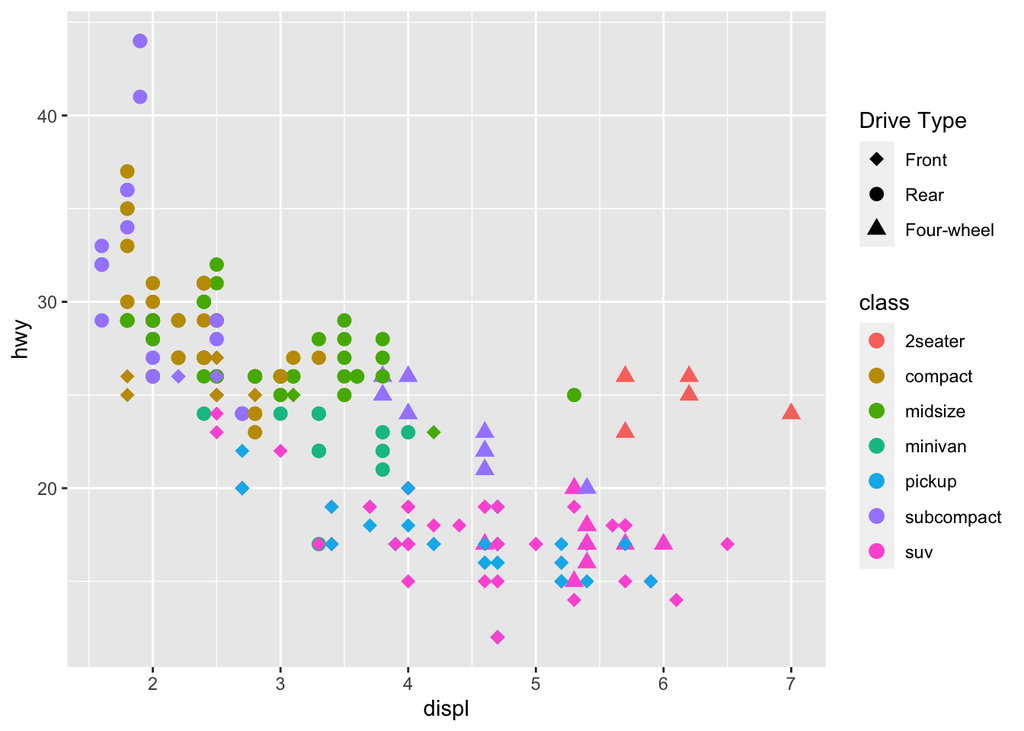

```r
plot4 <- ggplot(mpg, aes(x = displ, y = hwy, shape = drv)) +
  geom_point(aes(color = class), size = 3) +
  scale_shape_manual(
    name = "Drive Type",
    values = c("f" = 16, "r" = 17, "4" = 18),
    labels = c("Front", "Rear", "Four-wheel")
  )

print(plot4)
```

## 4.5 Exercise 5: Distinguished `ToothGrowth` Bar Chart

**Required Functions:** - `ggplot`, `geom_bar`, `scale_fill_manual`, `labs`, `theme`, `dplyr::group_by`, `dplyr::summarize`

**Load Dataset:**

```r
data(ToothGrowth)
```

**Solution Code:**

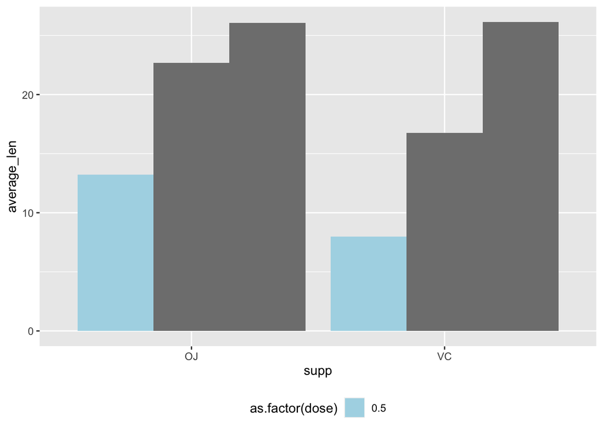

```r
library(dplyr)
library(ggplot2)

tooth_avg <- ToothGrowth %>%
  group_by(supp, dose) %>%
  summarize(average_len = mean(len))
plot5 <- ggplot(tooth_avg, aes(x = supp, y = average_len, fill = as.factor(dose))) +
  geom_bar(stat = "identity", position = "dodge") +
  scale_fill_manual(values = c("0.5" = "lightblue", "1.0" = "pink", "2.0" = "yellow")) +
  theme(legend.position = "bottom")

print(plot5)
```